# The role of response codes in spatial-numerical associations - Sixtus & Werner - ESCoP 2019

September 2019

# The Role of Response Codes in Spatial-Numerical Associations

Background:

Mental representation of numbers on a mental number line with a horizontal left-to-right (for Western cultures; Dehaene et al., 1993) or vertical bottom-to-top orientation for small to large numbers (Winter et al., 2015). Recent studies suggest that the vertical spatial-numerical association (SNA) is more robust than the horizontal SNA. Horizontal associations might be an artefact of the respective paradigms (Shaki & Fischer, 2018; Sixtus et al., 2019). We now investigated the relationship between the typical horizontal SNARC (spatial-numerical association of response codes) effect and two-dimensional SNAs with and without spatially distributed response buttons. We thereby aim to address the questions: *Is the SNARC effect an artifact of its response codes, i.e., spatially distributed response buttons?* How do SNAs that are spatially primed (i.e., SNARC) relate to conceptual SNAs?

# Preparations

## Libraries and shortcuts

```r
library(plyr)
library(afex)
library(ggplot2)
library(reshape)
library(data.table)

read_data <- function(directory, separator=","){
  x <- data.frame()
  for(i in list.files(directory)){
    i_dat <- read.delim(paste(directory,"/",i, sep = ""), comment.char="#", sep=separator, header=T)
    x <- rbind(x, i_dat)
  }
  return(x)
}

num <- function(x){
  as.numeric(as.character(x))
}

IES <- function(dat, FUN="mean"){
  dat$rt <- num(dat$rt)
  dat$correct <- num(dat$correct)
  if(FUN=="mean"){
    dat$ies <- mean(dat$rt, na.rm = T) / mean(dat$correct, na.rm = T)
  } else if(FUN=="median"){
    dat$ies <- median(dat$rt, na.rm = T) / mean(dat$correct, na.rm = T)
  }
  return(dat)
}

t_report <- function(ttest){
  if(ttest$p.value[[1]] < 0.001){
    p <- ", p < 0.001"
  }else{
    p <- paste0(", p = ", as.character(round(ttest$p.value[[1]], digits = 3)))
  }
  paste0("t(", ttest$parameter[[1]], ") = ", round(ttest$statistic[[1]], digits = 2), p)
}

bars <- stat_summary(fun.y=mean, geom="bar", position = position_dodge())
errorbars <-  stat_summary(fun.data="mean_se", geom="errorbar",position=position_dodge(width=0.10),width=0.2)
errorbars2 <-  stat_summary(fun.data="mean_se", geom="errorbar",position=position_dodge(width=0.90),width=0.2)
points <- stat_summary(fun.y=mean, geom="point")
points_big <- stat_summary(fun.y=mean, geom="point", size=3)
lines <- stat_summary(fun.y=mean, geom="line")
x_ax <- scale_x_continuous(breaks = c(1,2,8,9))
reg <- geom_smooth(method = lm, se=F)
hline <- geom_hline(yintercept = 0)
vline <- geom_vline(xintercept = 0)

cohens_dz <- function(ttest){
  dz <- abs(as.numeric(ttest[[1]])/sqrt(as.numeric(ttest[[2]]+1)))
  return(dz)
}

layout <- theme_bw() + theme(axis.text = element_text(size = 26),
                              axis.title=element_text(size=24, face = "bold"),
                              strip.text = element_text(size=18, face = "bold"),
                              strip.background = element_rect(fill="white"),
                              rect = element_rect(fill = "transparent"),
                              plot.background = element_rect(fill = "transparent", color = NA),
                              title = element_text(size= 22, face="bold"))

layout2 <- theme_bw() + theme(axis.text = element_text(size = 16),
                              axis.title=element_text(size=20, face = "bold"),
                              # legend.position = "top",
                              legend.text = element_text(size=9),
                              legend.title = element_text(size=10, face="bold"),
                              strip.text = element_text(size=10, face = "bold"),
                              strip.background = element_rect(fill="white"),
                              legend.position = "none")
```

# The three experiments

We conducted three experiments with the same group of participants which tested for 1) conceptual spatial-numerical associations (SNAs) in a Go/No-go setup including only one central response button, 2) SNAs in combination with alternating response codes (SNARC) including horizontally and vertically aligned response buttons, and 3) a rather conventional horizontal SNARC effect.

The first of the three experiments is very similar to https://doi.org/10.3389/fpsyg.2019.00172

The third of the three experiments is a standard SNARC experiment with a left and a right response button and a parity judgement task

In the second experiment, either the horizontally aligned buttons (same as in the third experiment) or the vertically aligned buttons had to be used for responses in a parity judgement task with auditorily presented numbers (1, 2, 8, 9). The response dimension (horizontally or vertically aligned buttons) was communicated via the colour of a central LED button. Responses were given with only one finger (index finger of dominant hand) and each trial was initiated by the participant pressing and holding the central button. The informative colour started after this inital button press. That is, the button board was a vertical wooden board with five buttons: top, right, bottom, left, central - the latter of which could change colour. The setup and experiments were built with arduino (https://www.arduino.cc) and expyriment (https://www.expyriment.org).

## find data sets with too many errors in any of the three experiments

## read MultiSNA

```r
snas <- read.csv2("snas.csv")
snas <- snas[snas$training=="experiment",]

errors_sna <- ddply(snas, .(subject_id), function(x)
  data.frame(n_correct_catch=length(x[x$correct==1 & x$catch==1,]$correct),
             n_correct_noncatch=length(x[x$correct==1 & x$catch==0,]$correct),
             n_incorrect_catch=length(x[x$correct==-1,]$correct),
             n_incorrect_noncatch=length(x[x$correct==0,]$correct)))

errorrate_catch <- length(snas[snas$correct==-1&snas$catch==1,]$correct) / length(snas[snas$correct%in%c(-1,1) & snas$catch==1,]$correct)
errorrate_noncatch <- length(snas[snas$correct==0&snas$catch==0,]$correct) / length(snas[snas$correct%in%c(0,1) & snas$catch==0,]$correct)

answers <- read.csv2("answers.csv")
snas <- merge(snas, answers, by="subject_id")
snas <- snas[snas$language != "nongerman",]

errors_sna$errorrate_catch <- errors_sna$n_incorrect_catch / (errors_sna$n_incorrect_catch+errors_sna$n_correct_catch)
errors_sna$errorrate_noncatch <- errors_sna$n_incorrect_noncatch / (errors_sna$n_incorrect_noncatch+errors_sna$n_correct_noncatch)


too_many_errors_SNA <- errors_sna[which(errors_sna$errorrate_catch > mean(errors_sna$errorrate_catch) + 3*sd(errors_sna$errorrate_catch)),]$subject_id

snas$target <- num(snas$target)
snas$position_index <- num(snas$position_index)
snas$rt <- num(snas$rt)
```

## read MultiSNARC

```r
snarc <- read.csv2("snarc.csv")
#during training
# snarc <- snarc[snarc$training=="training" & snarc$block==-1,]
#during experiment
snarc <- snarc[snarc$training == "experiment",]

snarc <- merge(snarc, answers, by="subject_id")

snarc <- snarc[snarc$language != "nongerman",]

# "correct" values:
# -999: middle button pressed
# -6: too slow (response)
# -5: too slow (release)
# -1: wrong dimension
print(paste("any incorrect responses: ", as.character(length(snarc[snarc$correct!=1,]$correct))))
```

```
## [1] "any incorrect responses:  409"
```

```r
print(paste("wrong dimension: ", as.character(length(snarc[snarc$correct==-1,]$correct))))
```

```
## [1] "wrong dimension:  168"
```

```r
print(paste("correct dimension, wrong button: ", as.character(length(snarc[snarc$correct==0,]$correct))))
```

```
## [1] "correct dimension, wrong button:  204"
```

```r
print(paste("too slow (release or response): ", as.character(length(snarc[snarc$correct%in%c(-5, -6),]$correct))))
```

```
## [1] "too slow (release or response):  27"
```

```r
print(paste("other error (middle button pressed): ", as.character(length(snarc[snarc$correct==-999,]$correct))))
```

```
## [1] "other error (middle button pressed):  10"
```

```r
errors_snarc <- ddply(snarc, .(subject_id), function(x)
  data.frame(n_correct=length(x[x$correct==1,]$correct),
             n_incorrect=length(x[x$correct!=1,]$correct)))

errors_snarc$errorrate <- errors_snarc$n_incorrect / (errors_snarc$n_incorrect+errors_snarc$n_correct)

too_many_errors_snarc <- errors_snarc[which(errors_snarc$errorrate > mean(errors_snarc$errorrate) + 3*sd(errors_snarc$errorrate)),]$subject_id
```

## read miniSNARC

```r
mini_dat <- read.csv2("mini_dat.csv")
mini_dat <- mini_dat[mini_dat$training == "experiment",]

mini_dat$rt <- num(mini_dat$rt)
mini_dat <- merge(mini_dat, answers, by="subject_id")

mini_dat <- mini_dat[mini_dat$language=="german",]

print(paste("any incorrect responses: ", as.character(length(mini_dat[mini_dat$correct!=1,]$correct))))
```

```
## [1] "any incorrect responses:  90"
```

```r
print(paste("too slow: ", as.character(length(mini_dat[mini_dat$correct==-1,]$correct))))
```

```
## [1] "too slow:  12"
```

```r
print(paste("wrong button: ", as.character(length(mini_dat[mini_dat$correct==0,]$correct))))
```

```
## [1] "wrong button:  78"
```

```r
errors_mini_dat <- ddply(mini_dat, .(subject_id), function(x)
  data.frame(n_correct=length(x[x$correct==1,]$correct),
             n_incorrect=length(x[x$correct!=1,]$correct)))

errors_mini_dat$errorrate <- errors_mini_dat$n_incorrect / (errors_mini_dat$n_incorrect+errors_mini_dat$n_correct)

too_many_errors_mini_dat <- errors_mini_dat[which(errors_mini_dat$errorrate > mean(errors_mini_dat$errorrate) + 3*sd(errors_mini_dat$errorrate)),]$subject_id
```

```r
snas <- snas[!snas$subject_id %in% too_many_errors_SNA & !snas$subject_id %in% too_many_errors_snarc & !snas$subject_id %in% too_many_errors_mini_dat,]
snarc <- snarc[!snarc$subject_id %in% too_many_errors_SNA & !snarc$subject_id %in% too_many_errors_snarc & !snarc$subject_id %in% too_many_errors_mini_dat,]
mini_dat <- mini_dat[!mini_dat$subject_id %in% too_many_errors_SNA & !mini_dat$subject_id %in% too_many_errors_snarc & !mini_dat$subject_id %in% too_many_errors_mini_dat,]
```

## overall RTs

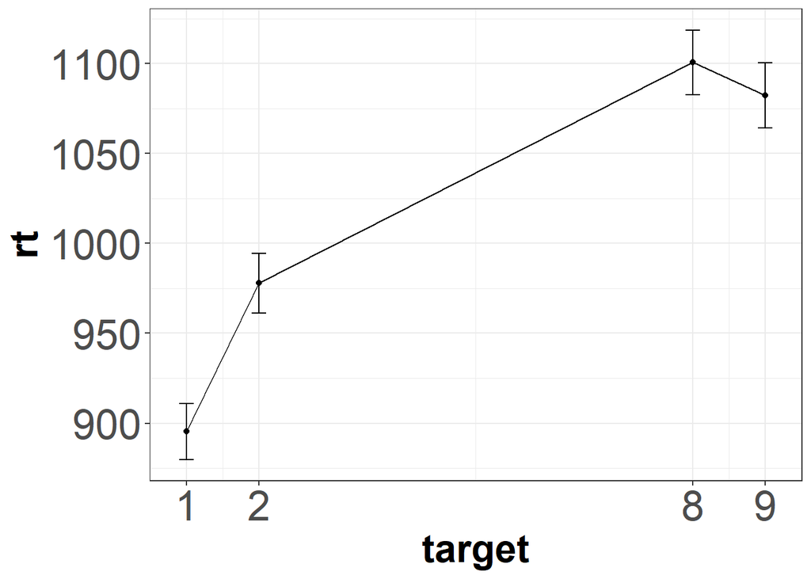

```r
s1 <- aggregate(data=snas, rt~subject_id+target,mean)
s2 <- aggregate(data=snarc, rt~subject_id+target,mean)
s3 <- aggregate(data=mini_dat, rt~subject_id+target,mean)
s1$experiment <- "2d_sna"
s2$experiment <- "2d_snarc"
s3$experiment <- "1d_snarc"

ggplot(s1, aes(target, rt)) + points + lines + errorbars + layout + scale_x_continuous(breaks = c(1, 2, 8, 9))
```

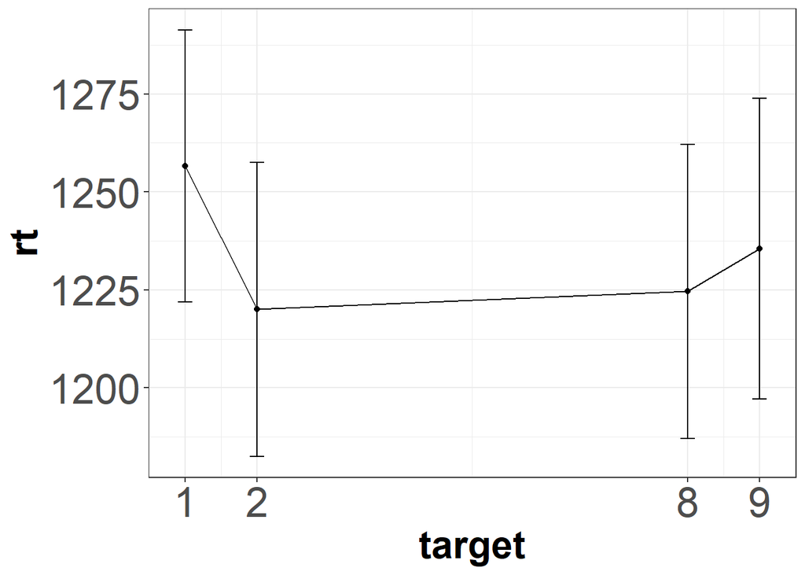

```r
ggplot(s2, aes(target, rt)) + points + lines + errorbars + layout + scale_x_continuous(breaks = c(1, 2, 8, 9))
```

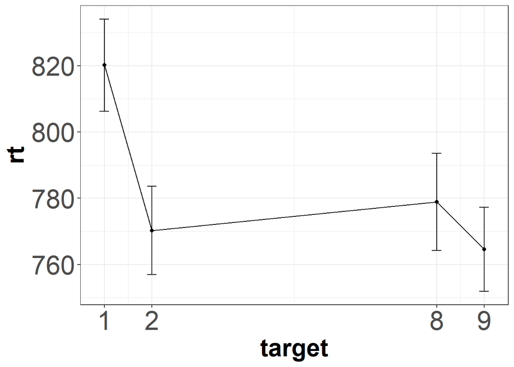

```r
ggplot(s3, aes(target, rt)) + points + lines + errorbars + layout + scale_x_continuous(breaks = c(1, 2, 8, 9))
```

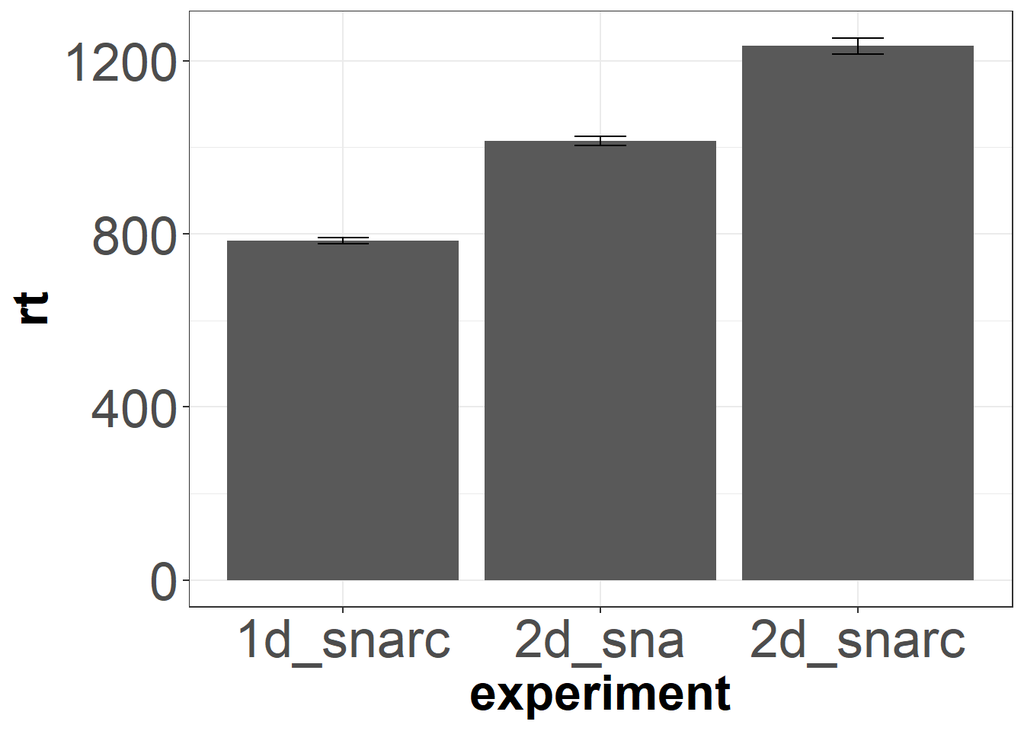

```r
ggplot(rbind(s1, s2, s3), aes(experiment, rt)) + bars + errorbars + layout
```

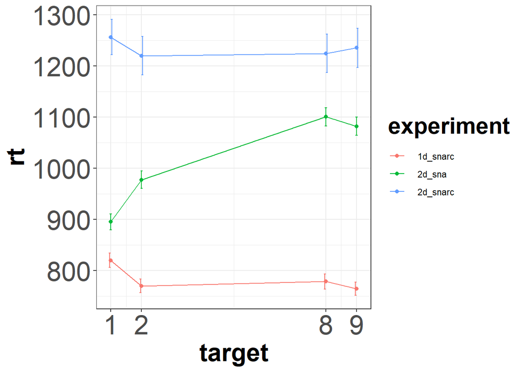

```r
ggplot(rbind(s1, s2, s3), aes(target, rt, colour=experiment)) + points + lines + errorbars + layout + scale_x_continuous(breaks = c(1, 2, 8, 9))
```

# MultiSNA

## preparations MultiSNA

```r
snas <- snas[snas$correct != -1,]

sna_noncatch <- snas[snas$catch == 0,]

sna_noncatch$side_position <- ifelse(sna_noncatch$position_index < 5, 1,
                                     ifelse(sna_noncatch$position_index < 10, 2,
                                            ifelse(sna_noncatch$position_index < 15, 3,
                                                   ifelse(sna_noncatch$position_index < 20, 4,5))))

sna_noncatch$side <- factor(sna_noncatch$side_position, labels=c("far_left", "left", "right", "far_right"))

sna_noncatch$generalside <- factor(ifelse(sna_noncatch$position_index < 10, 1,
                                     ifelse(sna_noncatch$position_index < 15, 2,
                                            3)),
                              labels=c("left", "right"))

sna_noncatch$vert_position <- (sna_noncatch$position_index %% 5) + 1
sna_noncatch$vert <- factor(sna_noncatch$vert_position, labels = c("far_down", "down", "up", "far_up"))

sna_noncatch$generalvert <- factor(ifelse(sna_noncatch$position_index %% 5 %in% c(0, 1), 1,
                                     ifelse(sna_noncatch$position_index %% 5 == 2, 2,
                                            3)),
                              labels=c("down", "up"))

sna_noncatch$quadrant <- factor(ifelse(sna_noncatch$generalside=="middle" | sna_noncatch$generalvert=="middle", 0,
                                       ifelse(sna_noncatch$generalvert=="up",
                                              ifelse(sna_noncatch$generalside=="left", 1, 2),
                                              ifelse(sna_noncatch$generalside=="left", 3, 4))),
                                       labels = c("LU", "RU", "LD", "RD"))

sna_noncatch$distance_from_middle <- ifelse(sna_noncatch$position_index == 12, 0,
                                            ifelse(sna_noncatch$position_index %in% c(6:8,11,13,16:18), 1,
                                                   ifelse(sna_noncatch$position_index %in% c(0:5,9,10,14,15,19:24), 2, 99)))

sna_noncatch$size_factor <- factor(ifelse(sna_noncatch$target < 5, 1, 2), labels = c("small", "large"))
sna <- sna_noncatch

data_agg <- ddply(sna, .(target, vert, side), summarize, mRT = mean(rt, na.rm=T), mER = 1-mean(correct, na.rm=T))
# no speed-accuracy tradeoff:
cor.test(data_agg$mRT, data_agg$mER)
```

```
##
##  Pearson's product-moment correlation
##
## data:  data_agg$mRT and data_agg$mER
## t = 5.0363, df = 62, p-value = 4.366e-06
## alternative hypothesis: true correlation is not equal to 0
## 95 percent confidence interval:
##  0.3377434 0.6928616
## sample estimates:
##       cor
## 0.5388197
```

```r
snarcy_hor_general_pre <- data.table(sna)[, .(ies=mean(rt, na.rm = T) / mean(correct, na.rm = T)), by=.(subject_id, generalside, target)]
snarcy_vert_general_pre <- data.table(sna)[, .(ies=mean(rt, na.rm = T) / mean(correct, na.rm = T)), by=.(subject_id, generalvert, target)]

snarcy_hor_general <- merge(snarcy_hor_general_pre[snarcy_hor_general_pre$generalside == "left",], snarcy_hor_general_pre[snarcy_hor_general_pre$generalside=="right",], by=c("subject_id", "target"))
snarcy_hor_general$RminusL <- snarcy_hor_general$ies.y - snarcy_hor_general$ies.x
snarcy_vert_general <- merge(snarcy_vert_general_pre[snarcy_vert_general_pre$generalvert == "down",], snarcy_vert_general_pre[snarcy_vert_general_pre$generalvert=="up",], by=c("subject_id", "target"))
snarcy_vert_general$UminusD <- snarcy_vert_general$ies.y - snarcy_vert_general$ies.x

snarcy_hor_general_slopes <- ddply(snarcy_hor_general, .(subject_id), function(x) coef(lm(RminusL ~ target, data=x)))
snarcy_vert_general_slopes <- ddply(snarcy_vert_general, .(subject_id), function(x) coef(lm(UminusD ~ target, data=x)))


##original rt
snarcy_hor_general_pre_rt <- aggregate(data=sna, rt ~ subject_id + generalside + target, mean)
snarcy_vert_general_pre_rt <- aggregate(data=sna, rt ~ subject_id + generalvert + target, mean)

snarcy_hor_general_rt <- merge(snarcy_hor_general_pre_rt[snarcy_hor_general_pre_rt$generalside == "left",],
                               snarcy_hor_general_pre_rt[snarcy_hor_general_pre_rt$generalside=="right",], by=c("subject_id", "target"))
snarcy_hor_general_rt$RminusL <- snarcy_hor_general_rt$rt.y - snarcy_hor_general_rt$rt.x
snarcy_vert_general_rt <- merge(snarcy_vert_general_pre_rt[snarcy_vert_general_pre_rt$generalvert == "down",],
                                snarcy_vert_general_pre_rt[snarcy_vert_general_pre_rt$generalvert=="up",], by=c("subject_id", "target"))
snarcy_vert_general_rt$UminusD <- snarcy_vert_general_rt$rt.y - snarcy_vert_general_rt$rt.x

snarcy_hor_general_slopes_rt <- ddply(snarcy_hor_general_rt, .(subject_id), function(x) coef(lm(RminusL ~ target, data=x)))
snarcy_vert_general_slopes_rt <- ddply(snarcy_vert_general_rt, .(subject_id), function(x) coef(lm(UminusD ~ target, data=x)))
```

## Prelim analyses

### some visualizations (RTs)

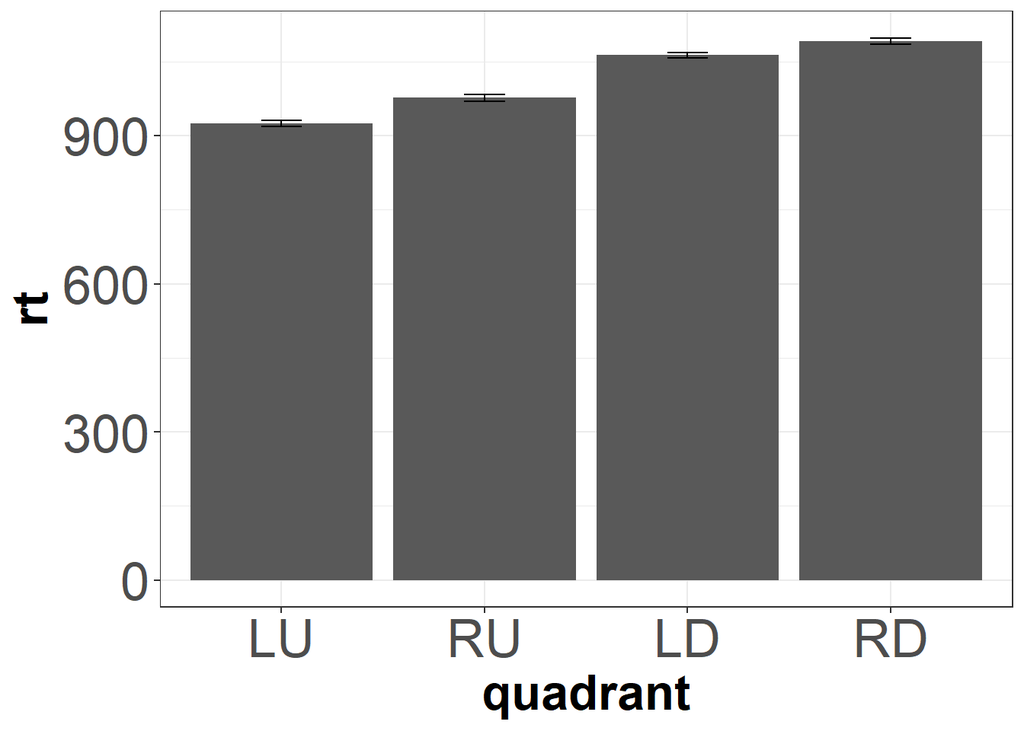

```r
ggplot(sna, aes(quadrant, rt)) + bars + errorbars + layout
```

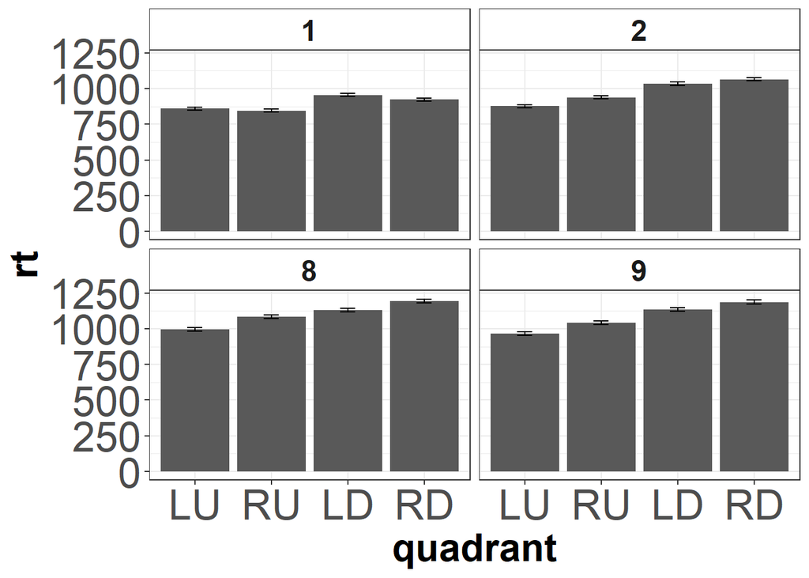

```r
ggplot(sna, aes(quadrant, rt)) + bars + errorbars + facet_wrap(~target) + layout
```

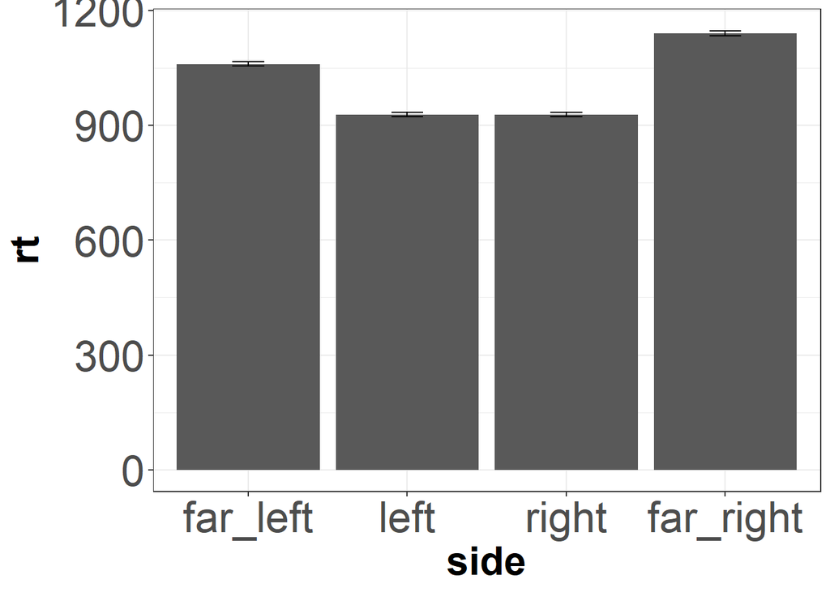

```r
ggplot(sna, aes(side, rt)) + bars + errorbars + layout
```

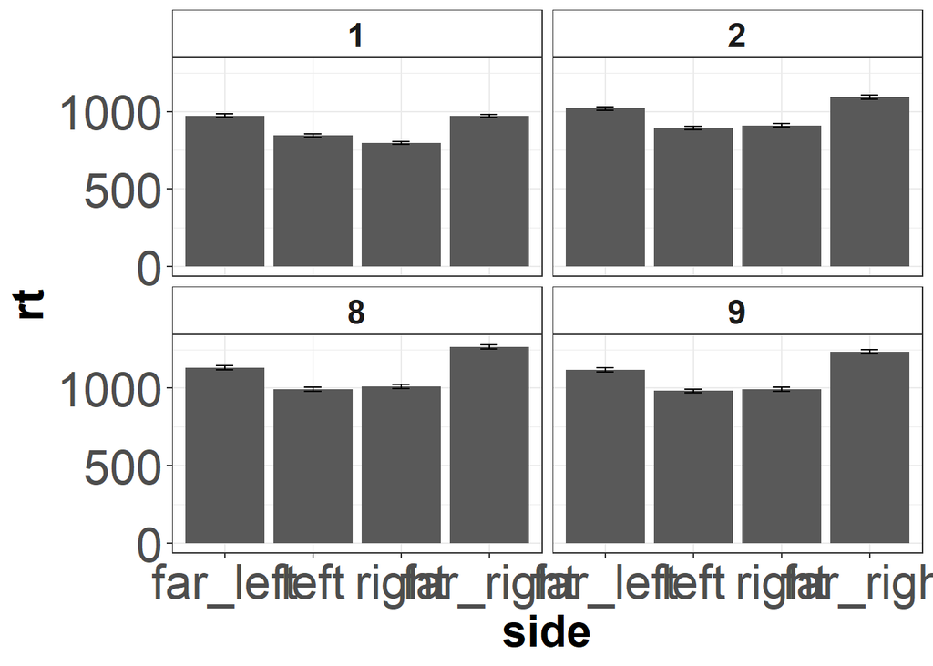

```r
ggplot(sna, aes(side, rt)) + bars + errorbars + facet_wrap(~target) + layout
```

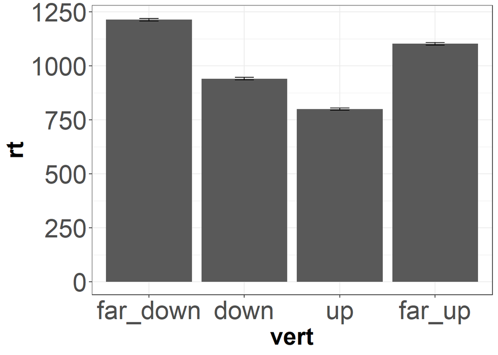

```r
ggplot(sna, aes(vert, rt)) + bars + errorbars + layout
```

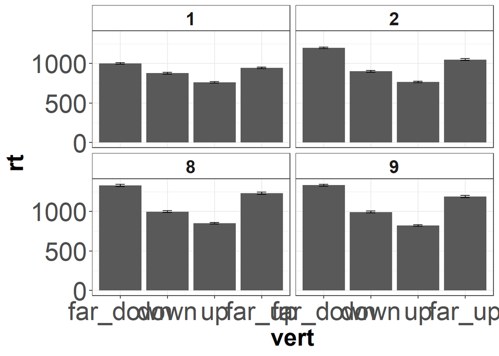

```r
ggplot(sna, aes(vert, rt)) + bars + errorbars + facet_wrap(~target) + layout
```

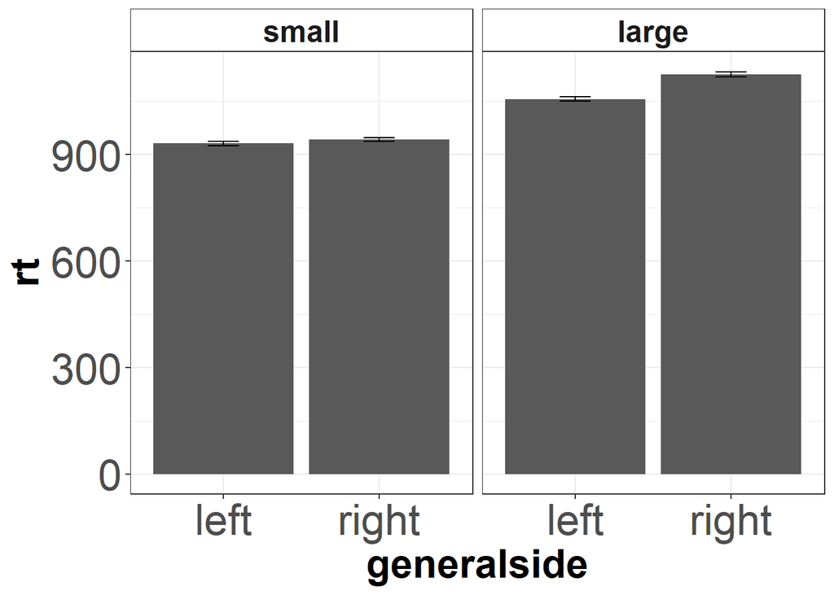

```r
ggplot(sna, aes(generalside, rt)) + bars + errorbars + facet_wrap(~size_factor) + layout
```

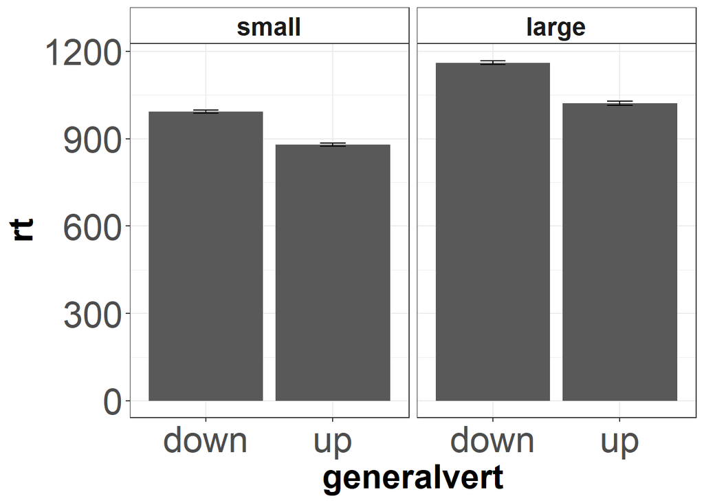

```r
ggplot(sna, aes(generalvert, rt)) + bars + errorbars + facet_wrap(~size_factor) + layout
```

```r
#RT general
ddply(sna, .(generalside), summarize, M=mean(rt, na.rm=T), SD=sd(rt, na.rm=T))
```

```
##   generalside        M       SD
## 1        left  993.573 445.1189
## 2       right 1033.629 469.2166
```

```r
ddply(sna, .(generalvert), summarize, M=mean(rt, na.rm=T), SD=sd(rt, na.rm=T))
```

```
##   generalvert         M       SD
## 1        down 1076.8269 453.3306
## 2          up  950.3505 453.4368
```

```r
side_rts <- aggregate(data=sna, rt ~ subject_id + generalside, mean)
t.test(side_rts$rt ~ side_rts$generalside, paired=T)
```

```
##
##  Paired t-test
##
## data:  side_rts$rt by side_rts$generalside
## t = -3.1363, df = 42, p-value = 0.003122
## alternative hypothesis: true difference in means is not equal to 0
## 95 percent confidence interval:
##  -65.56745 -14.22439
## sample estimates:
## mean of the differences
##               -39.89592
```

```r
print(paste0("Cohen's dz: ", round(cohens_dz(t.test(side_rts$rt ~ side_rts$generalside, paired=T)), digits = 2)))
```

```
## [1] "Cohen's dz: 0.48"
```

```r
vert_rts <- aggregate(data=sna, rt ~ subject_id + generalvert, mean)
t.test(vert_rts$rt ~ vert_rts$generalvert, paired=T)
```

```
##
##  Paired t-test
##
## data:  vert_rts$rt by vert_rts$generalvert
## t = 5.7774, df = 42, p-value = 8.3e-07
## alternative hypothesis: true difference in means is not equal to 0
## 95 percent confidence interval:
##   82.20125 170.45711
## sample estimates:
## mean of the differences
##                126.3292
```

```r
print(paste0("Cohen's dz: ", round(cohens_dz(t.test(vert_rts$rt ~ vert_rts$generalvert, paired=T)), digits = 2)))
```

```
## [1] "Cohen's dz: 0.88"
```

```r
#RT
ddply(sna, .(distance_from_middle), summarize, M=round(mean(rt, na.rm=T)), SD=round(sd(rt, na.rm=T)))
```

```
##   distance_from_middle    M  SD
## 1                    1  753 325
## 2                    2 1101 462
```

```r
sna_dist <- aggregate(data=sna, rt ~ subject_id + distance_from_middle, mean)
t.test(sna_dist$rt ~ sna_dist$distance_from_middle, paired=T)
```

```
##
##  Paired t-test
##
## data:  sna_dist$rt by sna_dist$distance_from_middle
## t = -29.701, df = 42, p-value < 2.2e-16
## alternative hypothesis: true difference in means is not equal to 0
## 95 percent confidence interval:
##  -372.0418 -324.7003
## sample estimates:
## mean of the differences
##               -348.3711
```

```r
print(paste0("Cohen's dz: ", round(cohens_dz(t.test(sna_dist$rt ~ sna_dist$distance_from_middle, paired=T)), digits = 2)))
```

```
## [1] "Cohen's dz: 4.53"
```

```r
#size
ddply(sna, .(size_factor), summarize, M=mean(rt, na.rm=T), SD=sd(rt, na.rm=T))
```

```
##   size_factor         M       SD
## 1       small  936.5168 407.3745
## 2       large 1091.0577 491.3090
```

```r
size_rts <- aggregate(data=sna, rt ~ subject_id + size_factor, mean)
t.test(size_rts$rt ~ size_rts$size_factor, paired = T)
```

```
##
##  Paired t-test
##
## data:  size_rts$rt by size_rts$size_factor
## t = -11.299, df = 42, p-value = 2.588e-14
## alternative hypothesis: true difference in means is not equal to 0
## 95 percent confidence interval:
##  -182.6454 -127.2890
## sample estimates:
## mean of the differences
##               -154.9672
```

```r
print(paste0("Cohen's dz: ", round(cohens_dz(t.test(size_rts$rt ~ size_rts$size_factor, paired = T)), digits = 2)))
```

```
## [1] "Cohen's dz: 1.72"
```

## General SNA(RC)

### horizontal

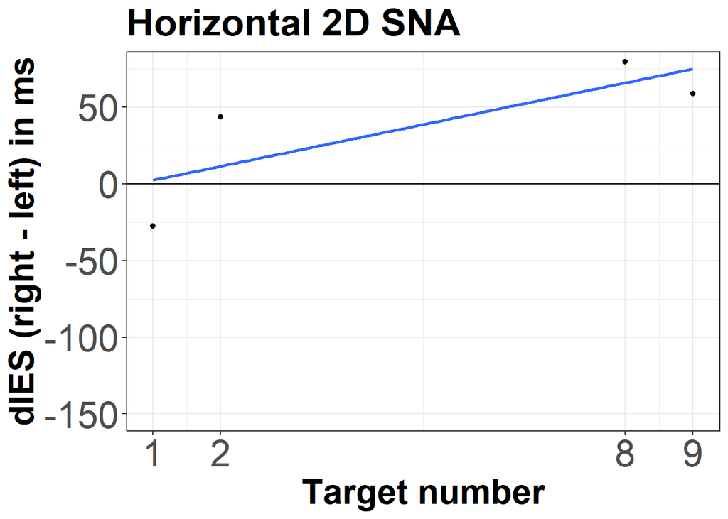

```r
ggplot(snarcy_hor_general, aes(target, RminusL)) +
  points +
  reg +
  x_ax +
  hline +
  coord_cartesian(ylim=c(-150, 75)) +
  labs(title="Horizontal 2D SNA", x = "Target number", y = "dIES (right - left) in ms") +
  layout
```

```r
ggsave("sna_hor_poster.png", width = 7, height = 5.5, units='in', dpi=600, bg="transparent")

t_hor_ies <- t.test(snarcy_hor_general_slopes$target, mu = 0)
t_hor_ies
```

```
##
##  One Sample t-test
##
## data:  snarcy_hor_general_slopes$target
## t = 3.662, df = 42, p-value = 0.0006946
## alternative hypothesis: true mean is not equal to 0
## 95 percent confidence interval:
##   4.070315 14.063628
## sample estimates:
## mean of x
##  9.066971
```

```r
t_report(t_hor_ies)
```

```
## [1] "t(42) = 3.66, p < 0.001"
```

```r
cohens_dz(t_hor_ies)
```

```
## [1] 0.5584538
```

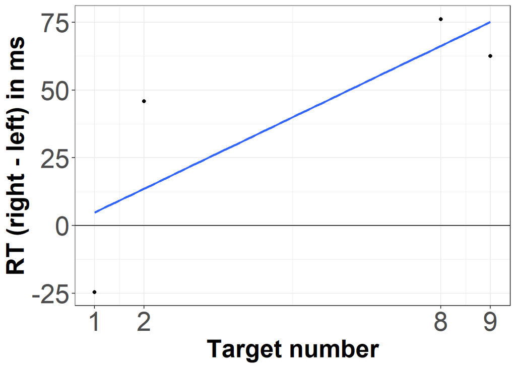

```r
ggplot(snarcy_hor_general_rt, aes(target, RminusL)) +
  points +
  reg +
  x_ax +
  layout +
  hline +
  #coord_cartesian(ylim=c(-120, 100)) +
  ylab("RT (right - left) in ms") +
  xlab("Target number")
```

```r
t_hor_rt <- t.test(snarcy_hor_general_slopes_rt$target, mu = 0)
t_hor_rt
```

```
##
##  One Sample t-test
##
## data:  snarcy_hor_general_slopes_rt$target
## t = 3.6093, df = 42, p-value = 0.0008113
## alternative hypothesis: true mean is not equal to 0
## 95 percent confidence interval:
##   3.874615 13.702745
## sample estimates:
## mean of x
##   8.78868
```

```r
t_report(t_hor_rt)
```

```
## [1] "t(42) = 3.61, p < 0.001"
```

```r
cohens_dz(t_hor_rt)
```

```
## [1] 0.5504112
```

### vertical

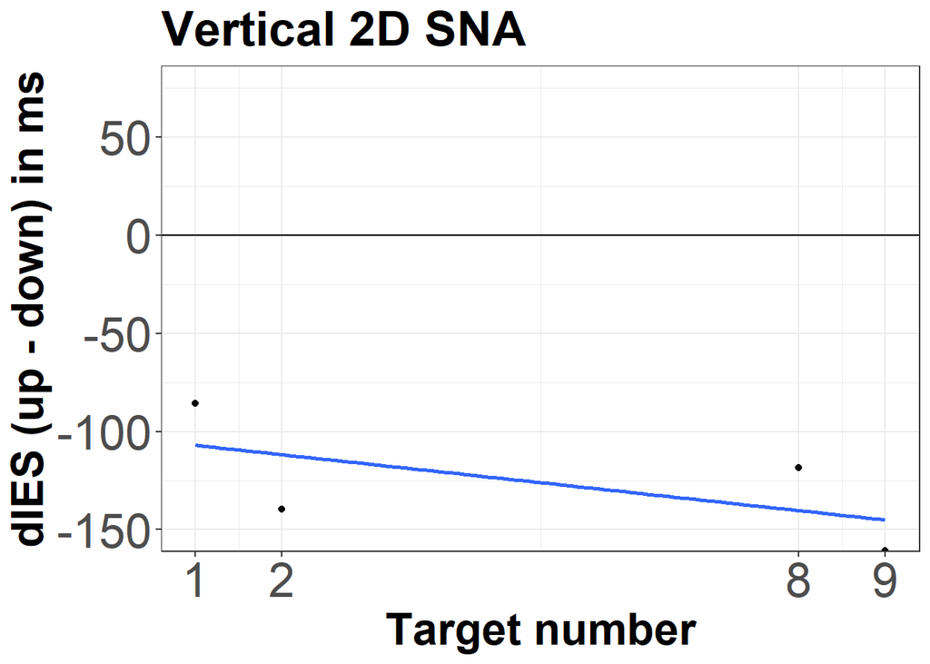

```r
ggplot(snarcy_vert_general, aes(target, UminusD)) +
  points +
  reg +
  x_ax +
  hline +
  coord_cartesian(ylim=c(-150, 75)) +
  ylab("dIES (up - down) in ms") +
  xlab("Target number") +
  labs(title="Vertical 2D SNA" ) +
  layout
```

```r
ggsave("sna_vert_poster.png", width = 7, height = 5.5, units='in', dpi=600, bg="transparent")
t_vert_ies <- t.test(snarcy_vert_general_slopes$target, mu = 0)
t_vert_ies
```

```
##
##  One Sample t-test
##
## data:  snarcy_vert_general_slopes$target
## t = -2.0728, df = 42, p-value = 0.04437
## alternative hypothesis: true mean is not equal to 0
## 95 percent confidence interval:
##  -9.3769341 -0.1253915
## sample estimates:
## mean of x
## -4.751163
```

```r
t_report(t_vert_ies)
```

```
## [1] "t(42) = -2.07, p = 0.044"
```

```r
cohens_dz(t_vert_ies)
```

```
## [1] 0.3160969
```

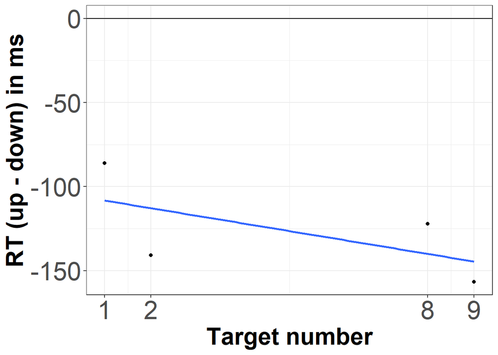

```r
ggplot(snarcy_vert_general_rt, aes(target, UminusD)) +
  points +
  reg +
  x_ax +
  layout +
  hline +
  #coord_cartesian(ylim=c(-120, 100)) +
  ylab("RT (up - down) in ms") +
  xlab("Target number")
```

```r
t_vert_rt <- t.test(snarcy_vert_general_slopes_rt$target, mu = 0)
t_vert_rt
```

```
##
##  One Sample t-test
##
## data:  snarcy_vert_general_slopes_rt$target
## t = -1.9971, df = 42, p-value = 0.05232
## alternative hypothesis: true mean is not equal to 0
## 95 percent confidence interval:
##  -9.11749697  0.04773205
## sample estimates:
## mean of x
## -4.534882
```

```r
t_report(t_vert_rt)
```

```
## [1] "t(42) = -2, p = 0.052"
```

```r
cohens_dz(t_vert_rt)
```

```
## [1] 0.304549
```

### comparison horizontal & vertical slopes

```r
compare_slopes <- t.test(snarcy_hor_general_slopes$target, snarcy_vert_general_slopes$target, paired = T)
compare_slopes
```

```
##
##  Paired t-test
##
## data:  snarcy_hor_general_slopes$target and snarcy_vert_general_slopes$target
## t = 3.9853, df = 42, p-value = 0.0002631
## alternative hypothesis: true difference in means is not equal to 0
## 95 percent confidence interval:
##   6.820927 20.815341
## sample estimates:
## mean of the differences
##                13.81813
```

```r
cohens_dz(compare_slopes)
```

```
## [1] 0.6077559
```

```r
compare_rt_slopes <- t.test(snarcy_hor_general_slopes_rt$target, snarcy_vert_general_slopes_rt$target, paired = T)
compare_rt_slopes
```

```
##
##  Paired t-test
##
## data:  snarcy_hor_general_slopes_rt$target and snarcy_vert_general_slopes_rt$target
## t = 3.8624, df = 42, p-value = 0.000382
## alternative hypothesis: true difference in means is not equal to 0
## 95 percent confidence interval:
##   6.362074 20.285051
## sample estimates:
## mean of the differences
##                13.32356
```

```r
cohens_dz(compare_rt_slopes)
```

```
## [1] 0.5890101
```

## Hor*Vert

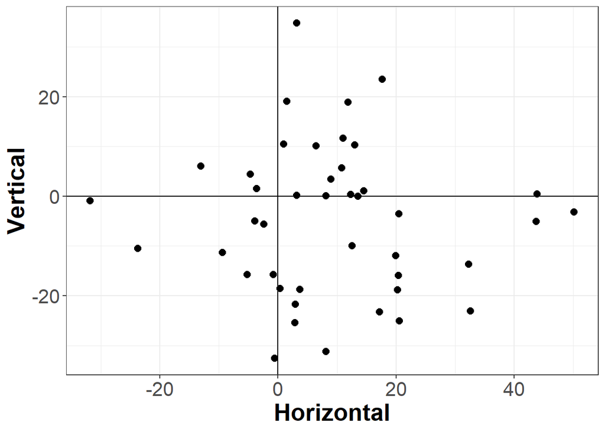

```r
slopes_ies <- merge(snarcy_hor_general_slopes, snarcy_vert_general_slopes, by="subject_id")
slopes_ies$Horizontal <- slopes_ies$target.x
slopes_ies$Vertical <- slopes_ies$target.y

ggplot(slopes_ies, aes(Horizontal, Vertical)) +
  geom_point(size=2.5) +
  hline +
  vline +
  layout2
```

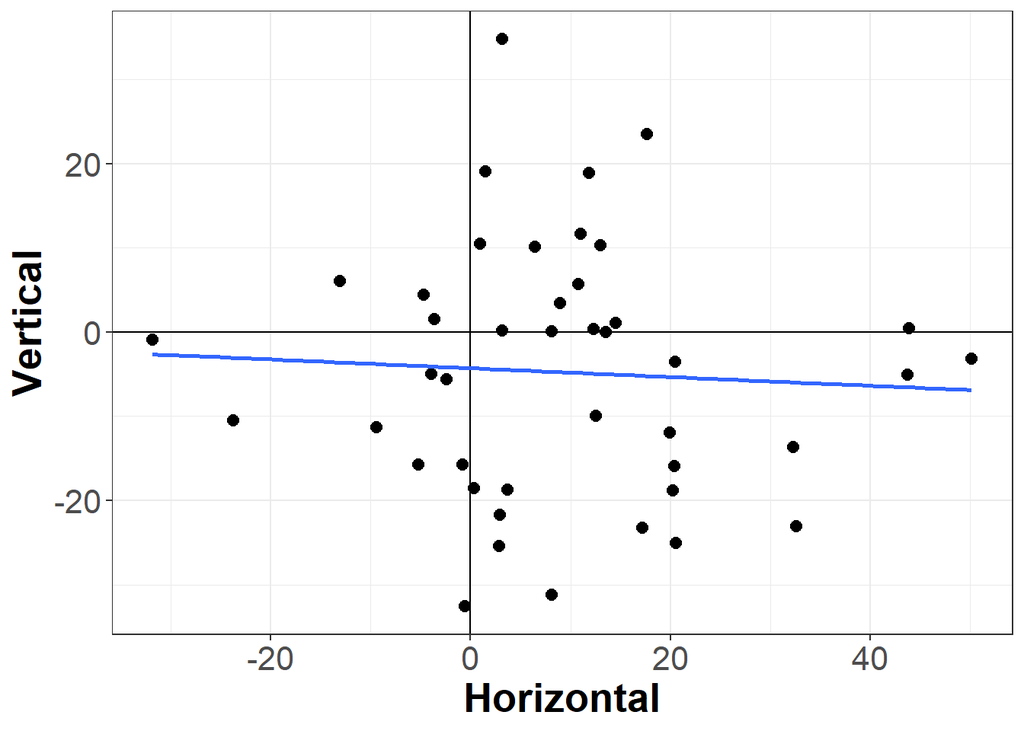

```r
ggplot(slopes_ies, aes(Horizontal, Vertical)) +
  geom_point(size=2.5) +
  hline +
  vline +
  layout2 + reg #+
```

```r
  #coord_cartesian(xlim=c(-20,20), ylim=c(-20, 20))

slopes_ies$Hor <- ifelse(slopes_ies$Horizontal < 0, "snarc", "reverse")
slopes_ies$Vert <- ifelse(slopes_ies$Vertical < 0, "snarc", "reverse")
ddply(slopes_ies, .(Hor), summarize, n = length(subject_id))
```

```
##       Hor  n
## 1 reverse 32
## 2   snarc 11
```

```r
ddply(slopes_ies, .(Vert), summarize, n = length(subject_id))
```

```
##      Vert  n
## 1 reverse 18
## 2   snarc 25
```

```r
ddply(slopes_ies, .(Hor,Vert), summarize, n = length(subject_id))
```

```
##       Hor    Vert  n
## 1 reverse reverse 15
## 2 reverse   snarc 17
## 3   snarc reverse  3
## 4   snarc   snarc  8
```

```r
cor.test(slopes_ies$Horizontal, slopes_ies$Vertical)
```

```
##
##  Pearson's product-moment correlation
##
## data:  slopes_ies$Horizontal and slopes_ies$Vertical
## t = -0.36023, df = 41, p-value = 0.7205
## alternative hypothesis: true correlation is not equal to 0
## 95 percent confidence interval:
##  -0.3505993  0.2483637
## sample estimates:
##         cor
## -0.05617013
```

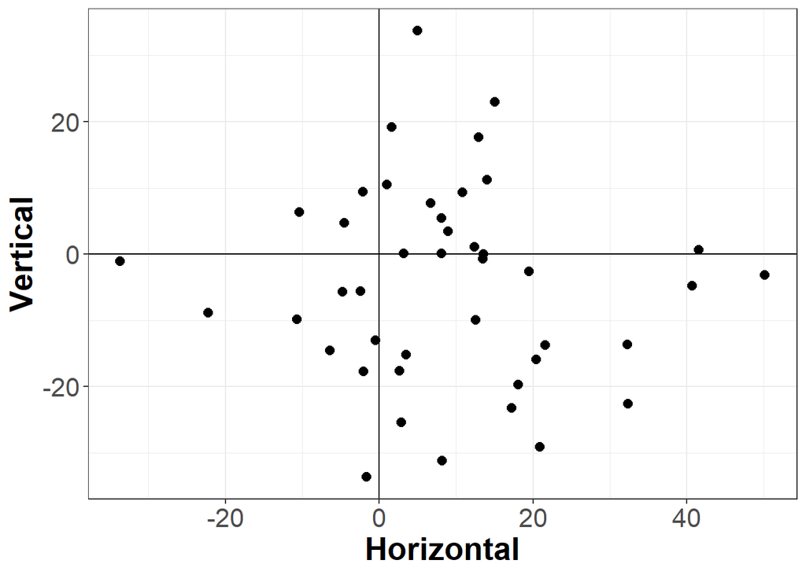

```r
slopes <- merge(snarcy_hor_general_slopes_rt, snarcy_vert_general_slopes_rt, by="subject_id")
slopes$Horizontal <- slopes$target.x
slopes$Vertical <- slopes$target.y

ggplot(slopes, aes(Horizontal, Vertical)) +
  geom_point(size=2.5) +
  hline +
  vline +
  layout2
```

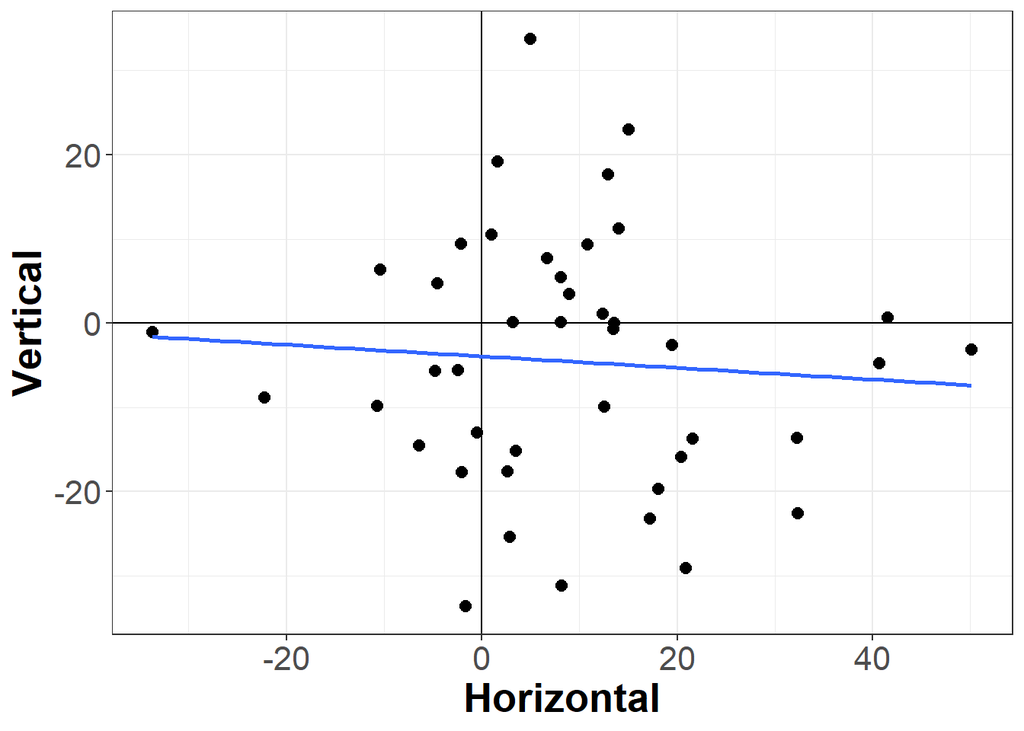

```r
ggplot(slopes, aes(Horizontal, Vertical)) +
  geom_point(size=2.5) +
  hline +
  vline +
  layout2 + reg #+
```

```r
  #coord_cartesian(xlim=c(-20,20), ylim=c(-20, 20))

slopes$Hor <- ifelse(slopes$Horizontal < 0, "snarc", "reverse")
slopes$Vert <- ifelse(slopes$Vertical < 0, "snarc", "reverse")
ddply(slopes, .(Hor), summarize, n = length(subject_id))
```

```
##       Hor  n
## 1 reverse 31
## 2   snarc 12
```

```r
ddply(slopes, .(Vert), summarize, n = length(subject_id))
```

```
##      Vert  n
## 1 reverse 17
## 2   snarc 26
```

```r
ddply(slopes, .(Hor,Vert), summarize, n = length(subject_id))
```

```
##       Hor    Vert  n
## 1 reverse reverse 14
## 2 reverse   snarc 17
## 3   snarc reverse  3
## 4   snarc   snarc  9
```

```r
cor.test(slopes$Horizontal, slopes$Vertical)
```

```
##
##  Pearson's product-moment correlation
##
## data:  slopes$Horizontal and slopes$Vertical
## t = -0.47242, df = 41, p-value = 0.6391
## alternative hypothesis: true correlation is not equal to 0
## 95 percent confidence interval:
##  -0.3658390  0.2318885
## sample estimates:
##         cor
## -0.07357997
```

# MultiSNARC

## preparations MultiSNARC

```r
snarc_complete <- snarc
snarc <- snarc[snarc$correct==1,]
```

```r
snarc$size <- factor(ifelse(snarc$target < 5, 1, 2), labels = c("small", "large"))
snarc$parity <- factor(ifelse(snarc$target%%2==0, 1, 2), labels=c("even", "odd"))
snarc$button <- factor(ifelse(snarc$pressed_button == "b'le'", 1, ifelse(snarc$pressed_button == "b'ri'", 2, ifelse(snarc$pressed_button == "b'do'", 3, ifelse(snarc$pressed_button=="b'up'", 4, 9)))), labels = c("left", "right", "down", "up"))
```

## pre-visualizations

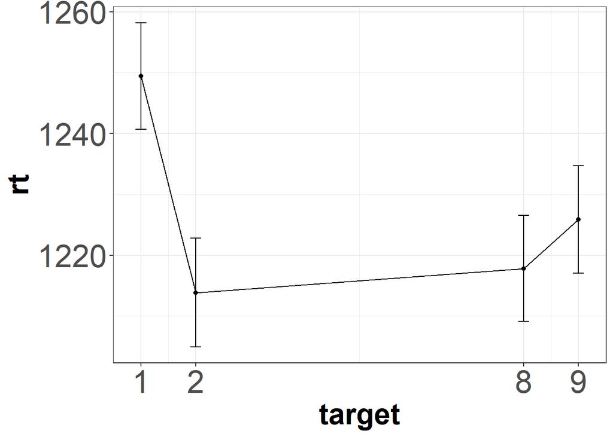

```r
ggplot(snarc, aes(target, rt)) + lines + points + errorbars + x_ax + layout
```

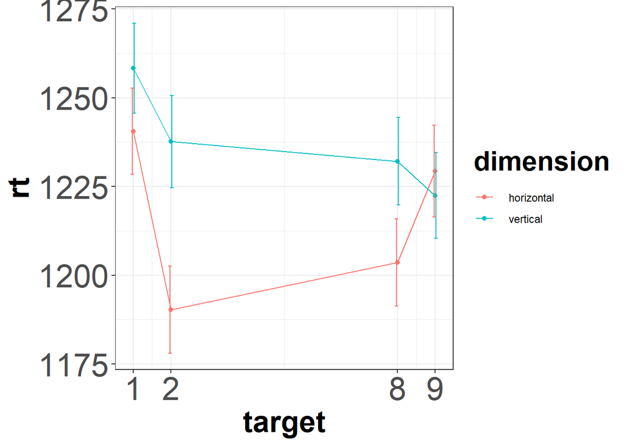

```r
ggplot(snarc, aes(target, rt, colour=dimension)) + lines + points + errorbars + x_ax + layout
```

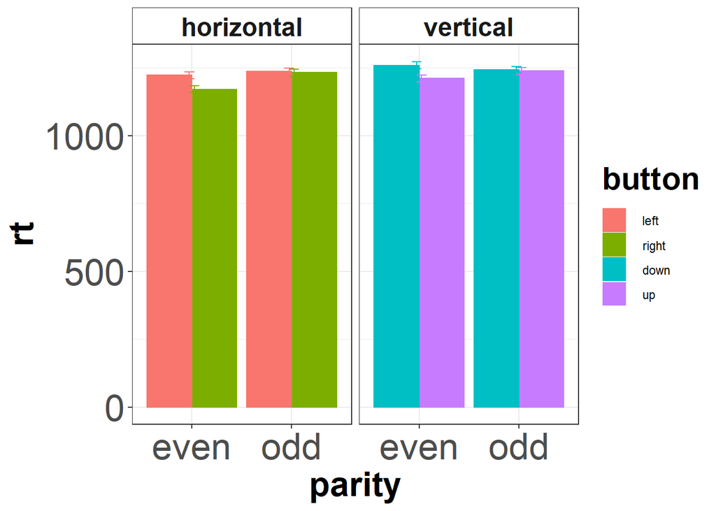

```r
ggplot(snarc, aes(parity, rt, colour=button, fill=button)) + bars + errorbars + facet_wrap(~dimension, ncol = 4) + layout
```

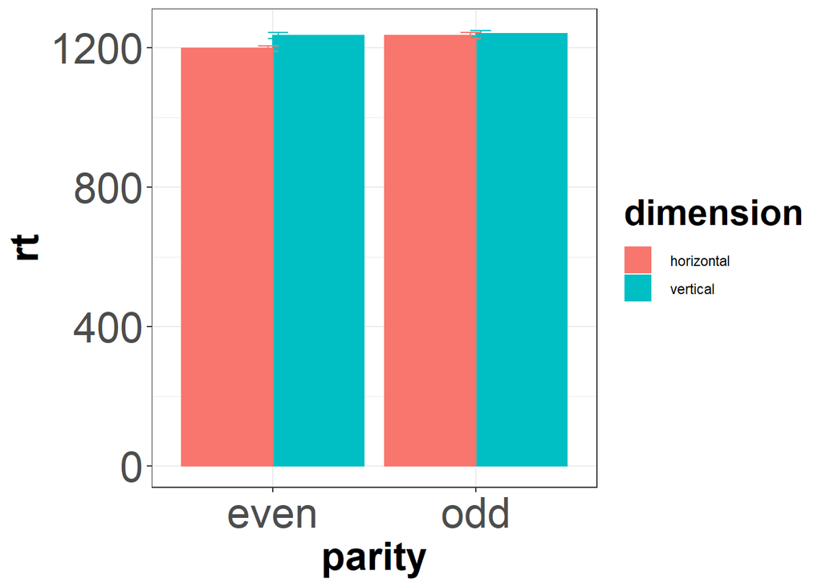

```r
ggplot(snarc, aes(parity, rt, colour=dimension, fill=dimension)) + bars + errorbars + layout
```

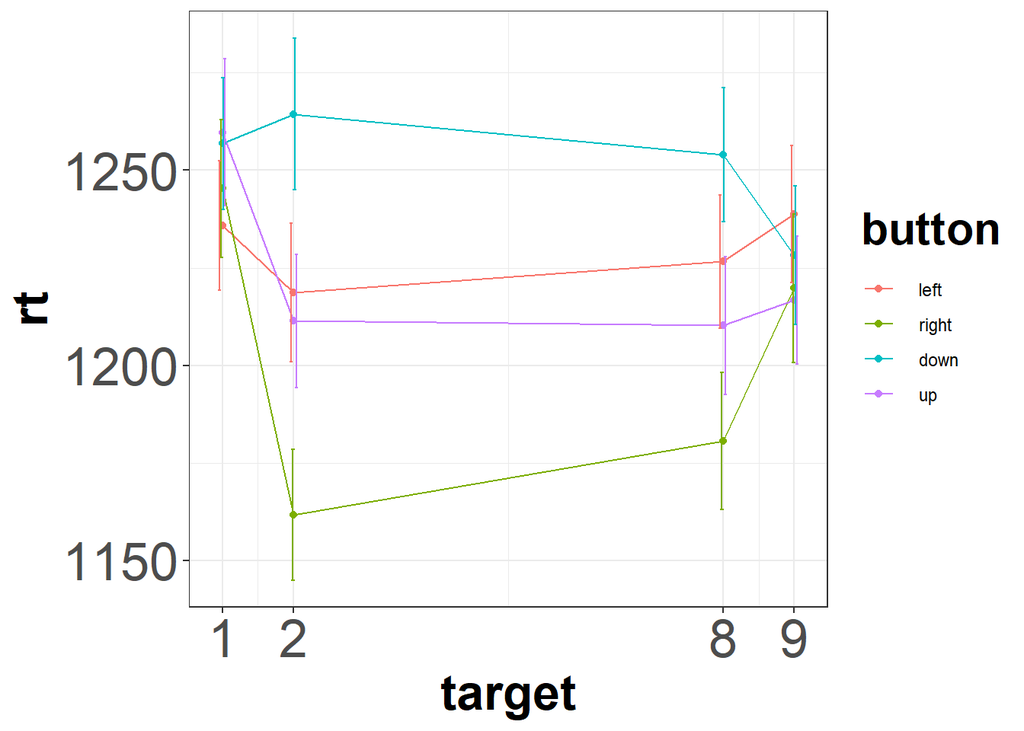

```r
ggplot(snarc, aes(target, rt, colour=button)) + lines + points + errorbars + x_ax + layout
```

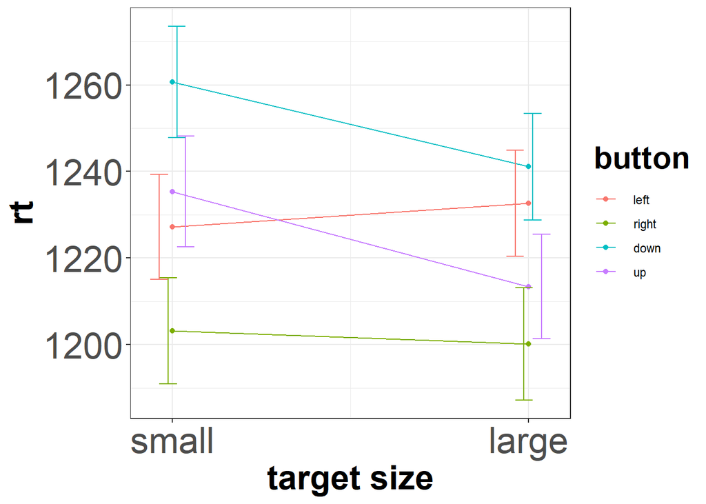

```r
ggplot(snarc, aes(as.integer(target>5), rt, colour=button)) + lines + points + errorbars +  layout + scale_x_continuous(breaks = c(0, 1), labels = c("small", "large")) + labs(x = "target size")
```

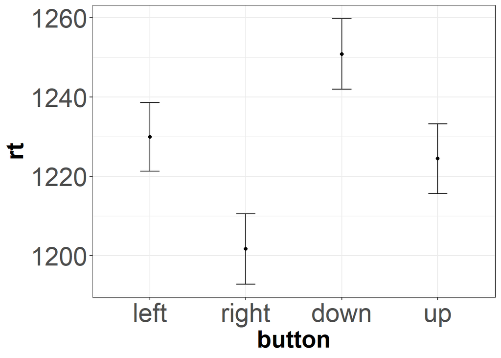

```r
#reaction time
ggplot(snarc, aes(button, rt)) + points + errorbars + layout
```

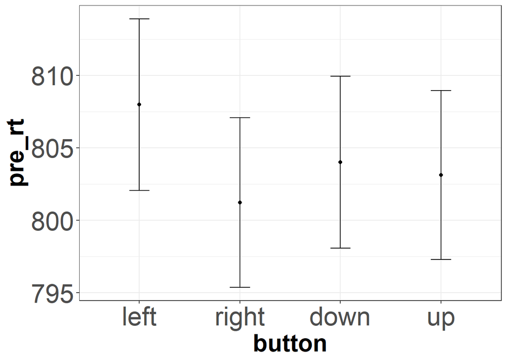

```r
#part of rt from target presentation until release of central button (pre-reaction time)
ggplot(snarc, aes(button, pre_rt)) + points + errorbars + layout
```

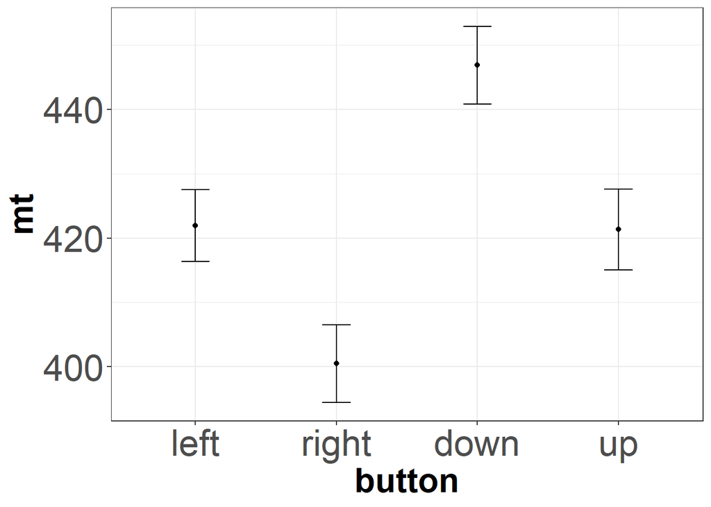

```r
#part of rt from release of central button until press of response button (movement time)
ggplot(snarc, aes(button, mt)) + points + errorbars + layout
```